# Lab 2a[^1]

## 4.1 Multiple transformations with `%>%`

Write code to perform the following operations using `dplyr` functions and pipes:

1. Select three columns from `msleep` (the variables “name”, “order” and “sleep_total”)
2. Arrange the rows by `order` and by `sleep_total` in descending order.
3. Filter the rows for mammals that sleep 16 or more hours.
4. Show the first 5 lines of the resulting transformation.

```r
msleep %>%
    dplyr::select(name, order, sleep_total) %>%
    dplyr::arrange(order, desc(sleep_total)) %>%
    dplyr::filter(sleep_total >= 16) %>%
    head(n=5)
```

| name | order | sleep_total |
| --- | --- | --- |
| Little brown bat | Chiroptera | 19.9 |
| Big brown bat | Chiroptera | 19.7 |
| Giant armadillo | Cingulata | 18.1 |
| Long-nosed armadillo | Cingulata | 17.4 |
| Thick-tailed opposum | Didelphimorphia | 19.4 |

### 4.1.1 Create new columns using `dplyr::mutate()`

The `dplyr::mutate()` function will add new columns to the data frame. Create a new column called `rem_proportion`, which is calculated as the following ratio: `rem_proportion = sleep_rem / sleep_total`. Show the first 5 rows of the result.

```r
msleep %>%
    dplyr::mutate(rem_proportion = sleep_rem / sleep_total) %>%
    dplyr::slice_head(n=5)
```

| name | genus | vore | order | conservation | sleep_total | sleep_rem | sleep_cycle | awake | brainwt | bodywt | rem_proportion |
| --- | --- | --- | --- | --- | --- | --- | --- | --- | --- | --- | --- |
| Cheetah | Acinonyx | carni | Carnivora | lc | 12.1 | NA | NA | 11.9 | NA | 50.000 | NA |
| Owl monkey | Aotus | omni | Primates | NA | 17.0 | 1.8 | NA | 7.0 | 0.01550 | 0.480 | 0.1058824 |
| Mountain beaver | Aplodontia | herbi | Rodentia | nt | 14.4 | 2.4 | NA | 9.6 | NA | 1.350 | 0.1666667 |
| Greater short-tailed shrew | Blarina | omni | Soricomorpha | lc | 14.9 | 2.3 | 0.1333333 | 9.1 | 0.00029 | 0.019 | 0.1543624 |
| Cow | Bos | herbi | Artiodactyla | domesticated | 4.0 | 0.7 | 0.6666667 | 20.0 | 0.42300 | 600.000 | 0.1750000 |

You can add several new columns using `dplyr::mutate()` (separated by commas).

Write code to:

1. Create two new variables in `msleep`:
   - `rem_proportion = sleep_rem / sleep_total`
   - `brain_body = brainwt / bodywt`
2. Save the `msleep` data with these new variables as `sleepdata`.
3. Verify that `sleepdata` indeed contains the two new variables.

```r
sleepdata <- msleep %>%
    dplyr::mutate(rem_proportion = sleep_rem / sleep_total,
           brain_body = brainwt / bodywt) %>%
  glimpse()
```

```
Rows: 83
Columns: 13
$ name           <chr> "Cheetah", "Owl monkey", "Mountain beaver", "Greater short-tailed shrew", "Cow", "Th…
$ genus          <chr> "Acinonyx", "Aotus", "Aplodontia", "Blarina", "Bos", "Bradypus", "Callorhinus", "Cal…
$ vore           <chr> "carni", "omni", "herbi", "omni", "herbi", "herbi", "carni", NA, "carni", "herbi", "…
$ order          <chr> "Carnivora", "Primates", "Rodentia", "Soricomorpha", "Artiodactyla", "Pilosa", "Carn…
$ conservation   <chr> "lc", NA, "nt", "lc", "domesticated", NA, "vu", NA, "domesticated", "lc", "lc", "dom…
$ sleep_total    <dbl> 12.1, 17.0, 14.4, 14.9, 4.0, 14.4, 8.7, 7.0, 10.1, 3.0, 5.3, 9.4, 10.0, 12.5, 10.3, …
$ sleep_rem      <dbl> NA, 1.8, 2.4, 2.3, 0.7, 2.2, 1.4, NA, 2.9, NA, 0.6, 0.8, 0.7, 1.5, 2.2, 2.0, 1.4, 3.…
$ sleep_cycle    <dbl> NA, NA, NA, 0.1333333, 0.6666667, 0.7666667, 0.3833333, NA, 0.3333333, NA, NA, 0.216…
$ awake          <dbl> 11.90, 7.00, 9.60, 9.10, 20.00, 9.60, 15.30, 17.00, 13.90, 21.00, 18.70, 14.60, 14.0…
$ brainwt        <dbl> NA, 0.01550, NA, 0.00029, 0.42300, NA, NA, NA, 0.07000, 0.09820, 0.11500, 0.00550, N…
$ bodywt         <dbl> 50.000, 0.480, 1.350, 0.019, 600.000, 3.850, 20.490, 0.045, 14.000, 14.800, 33.500, …
$ rem_proportion <dbl> NA, 0.10588235, 0.16666667, 0.15436242, 0.17500000, 0.15277778, 0.16091954, NA, 0.28…
$ brain_body     <dbl> NA, 0.032291667, NA, 0.015263158, 0.000705000, NA, NA, NA, 0.005000000, 0.006635135,…
```

Check whether there is a relationship between the total amount of sleep (`sleep_total`) mammals need, and the ratio of the brain weight compared to the body weight (`brain_body`). Do mammals with relatively larger brains need more sleep? Make the plot with the following code. What do you conclude from the plot?

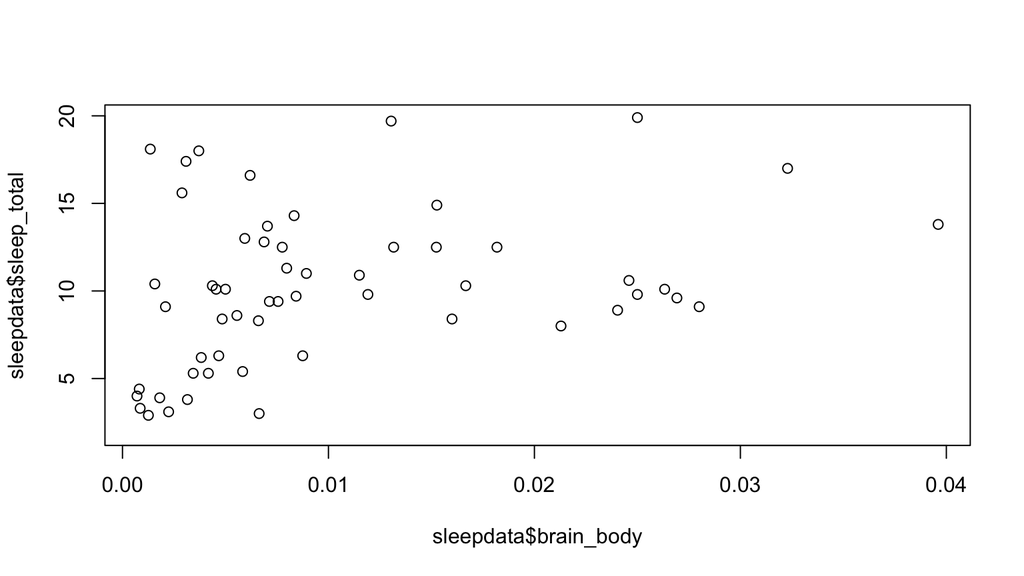

```r
plot(sleepdata$brain_body, sleepdata$sleep_total)
```

### 4.1.2 Pipe operator and model formula

A step further would be to fit a linear regression model, with total hours of sleep as outcome variable (`y = sleep_total`) and the ratio between brain weight and body weight as independent variable (`x = brain_body`).

In R we fit linear regression models with: `lm(y ~ x, data = data_frame)`.

Look at the code below and see if you understand what it does. Why do we need to use `data = .` as an argument in the `lm()` function?

```r
msleep %>%
    dplyr::mutate(rem_proportion = sleep_rem / sleep_total,
           brain_body = brainwt / bodywt) %>%
    lm(sleep_total ~ brain_body, data = .) %>%
    summary()
```

```
Call:
lm(formula = sleep_total ~ brain_body, data = .)

Residuals:
   Min     1Q Median     3Q    Max
-6.606 -3.420 -0.477  2.107  9.297

Coefficients:
            Estimate Std. Error t value Pr(>|t|)
(Intercept)   8.5973     0.8529  10.080 5.16e-14 ***
brain_body  152.0003    61.6672   2.465   0.0169 *
---
Signif. codes:  0 '***' 0.001 '**' 0.01 '*' 0.05 '.' 0.1 ' ' 1

Residual standard error: 4.231 on 54 degrees of freedom
  (27 observations deleted due to missingness)
Multiple R-squared:  0.1011,    Adjusted R-squared:  0.08449
F-statistic: 6.075 on 1 and 54 DF,  p-value: 0.01692
```

# 5 Create summaries with `dplyr::summarise()`

The `summarise()` function creates summary statistics for a given column in the data frame such as the mean. Write code that calculates the following statistics on the variable `sleep_total` and give the values useful names:

- average
- minimum
- maximum
- total number of observations

```r
msleep %>%
    dplyr::summarise(avg_sleep = mean(sleep_total),
              min_sleep = min(sleep_total),
              max_sleep = max(sleep_total),
              total = n())
```

| avg_sleep | min_sleep | max_sleep | total |
| --- | --- | --- | --- |
| 10.43373 | 1.9 | 19.9 | 83 |

# 6 Dealing with missing data

The variable `sleep_cycle` has missing values. If you use the code below to compute summary statistics for this variable, it will return `NA` (missing value) for the summary statistics.

```
msleep %>%
    dplyr::summarise(avg_sleep_cycle = mean(sleep_cycle),
              min_sleep_cycle = min(sleep_cycle),
              max_sleep_cycle = max(sleep_cycle),
              total = n())
```

Try the code in de chunk below and make necessary adjustments to the code to be able to compute summary statistics.

```r
# Solutions to deal with missing values: na.rm = TRUE
msleep %>%
    dplyr::summarise(avg_sleep_cycle = mean(sleep_cycle, na.rm = TRUE),
              min_sleep_cycle = min(sleep_cycle, na.rm = TRUE),
              max_sleep_cycle = max(sleep_cycle, na.rm = TRUE),
              total = n())
```

| avg_sleep_cycle | min_sleep_cycle | max_sleep_cycle | total |
| --- | --- | --- | --- |
| 0.4395833 | 0.1166667 | 1.5 | 83 |

### 6.0.1 Grouping data: `dplyr::group_by()`

Split the `msleep` data frame by the type of food the animals eat (the `vore` variable), then ask for the summary statistics average, minimum and maximum, plus the total number of observations in each `vore` category. The result should give a set of summary statistics for each `vore` type.

```r
msleep %>%
    dplyr::group_by(vore) %>%
    dplyr::summarise(
              avg_sleep = mean(sleep_total),
              min_sleep = min(sleep_total),
              max_sleep = max(sleep_total),
              total = n())
```

| vore | avg_sleep | min_sleep | max_sleep | total |
| --- | --- | --- | --- | --- |
| carni | 10.378947 | 2.7 | 19.4 | 19 |
| herbi | 9.509375 | 1.9 | 16.6 | 32 |
| insecti | 14.940000 | 8.4 | 19.9 | 5 |
| omni | 10.925000 | 8.0 | 18.0 | 20 |
| NA | 10.185714 | 5.4 | 13.7 | 7 |

### 6.0.2 Save the `msleep` data as .Rdata

If you want to save your data, you can use the `R` native format of an `.Rdata` file. Use the following code to save the `msleep` data to your current project directory. Verify where the data have been saved.

```r
save(msleep, file="msleep.RData")
```

## 6.1 Close the project

Close the RStudio Project using the option you prefer.

Here are the 2 options:

1. Quit RStudio using RStudio -> Quit RStudio. This will close the RStudio application but keep the current RStudio Project active. This means that when you open RStudio the next time, it will automatically open with the current RStudio Project.
2. Close the RStudio Project using File -> Close Project. This will only close the current RStudio Project, but it will not close the RStudio application.

# 7 Advanced exercises

### 7.0.1 Create new variables based on conditions with `dplyr::mutate()`

Create a new variable `sleep_length` with two levels: “long” when the animals sleeps equal to or more than 10 hours (variable `sleep_total`) and “normal” when the animals sleep less than 10 hours in total. Save the new data set with this extra variable under a new name. Ensure that the new variable is a factor with two levels. Verify the results with the `summary()` function for the new variable `sleep_length`. Hint: use the `dplyr` function `mutate()` in combination with `if_else`.

```r
newdata <- msleep %>%
  mutate(sleep_length = if_else(condition = sleep_total >= 10,
                        true = "long",
                        false = "normal"),
         sleep_length = factor(sleep_length))

summary(newdata$sleep_length)
```

```
  long normal
    45     38
```

## 7.1 Use `case_when` to recode variables

Now create another variable `sleep_cat` based on `sleep_total` and this time using three categories: animals that sleep 6 hours or less are “short”, animals that sleep between 6 and 10 hours are “normal”, and animals that sleep more than 10 hours are “long”. Create a new data set with this new variable included as a factor. Use the function `case_when()` and save the data set with the new variable under a new name.

```r
newdata2 <- newdata %>%
  mutate(sleep_cat = case_when(
            sleep_total <= 6 ~ "short",
            sleep_total > 10  ~ "long",
            TRUE ~ "normal"),
 sleep_cat = factor(sleep_cat)
        )

summary(newdata2$sleep_cat)
```

```
  long normal  short
    44     23     16
```

### 7.1.1 Change the levels of a categorical variable with `dplyr` and `case_when`

Create a new variable `vore_cat` that combines the two categories “carni” and “insecti” in the original variable `vore`. Save the new data set under a new name and ensure that the new variable `vore-cat` is converted to a factor variable.

```r
newdata3 <- msleep %>%
  mutate(vore_cat = case_when(
            vore == "carni" ~ "carni",
            vore == "insecti" ~ "carni",
            vore == "herbi" ~ "herbi",
            vore == "omni" ~ "omni"),
 vore_cat = factor(vore_cat)
        )

summary(newdata3$vore_cat)
```

```
carni herbi  omni  NA's
   24    32    20     7
```

### 7.1.2 Exclude a few animals from the data set with base R code and with `dplyr`

```r
# The first approach uses the names
exclude <- c("Bottle-nosed dolphin", "Lesser short-tailed shrew", "Musk shrew")
which <- msleep$name %in% exclude #Indicate the species that match the names in exclude
which
```

```
 [1] FALSE FALSE FALSE FALSE FALSE FALSE FALSE FALSE FALSE FALSE FALSE FALSE FALSE FALSE FALSE FALSE  TRUE
[18] FALSE FALSE FALSE FALSE FALSE FALSE FALSE FALSE FALSE FALSE FALSE FALSE FALSE FALSE FALSE FALSE FALSE
[35] FALSE FALSE FALSE FALSE FALSE FALSE FALSE FALSE FALSE FALSE FALSE FALSE FALSE FALSE FALSE FALSE FALSE
[52] FALSE FALSE FALSE FALSE FALSE FALSE FALSE FALSE FALSE FALSE FALSE FALSE FALSE FALSE FALSE FALSE FALSE
[69] FALSE FALSE FALSE FALSE  TRUE FALSE FALSE FALSE FALSE FALSE FALSE  TRUE FALSE FALSE FALSE
```

```r
msleep2 <- msleep[!which, ]
```

```r
# The second approach uses the row numbers directly (you would need to inquire about, or calculate the row numbers)
msleep3 <- msleep[-c(17, 73, 80), ]

# Note that the numbered option requires less code, but the named option has a much lower probability for error. As the data set might change, or might get sorted differently, the second option may not be valid anymore.
```

```r
# Using dplyr and filter()

library(dplyr)
exclude <- c("Bottle-nosed dolphin", "Lesser short-tailed shrew", "Musk shrew")
msleep4 <- dplyr::filter(msleep, !msleep$name %in% exclude) # ! makes all TRUES into FALSE
```

### 7.1.3 Close the project

Close the RStudio Project using the option you prefer.

Here are the 2 options:

1. Quit RStudio using RStudio -> Quit RStudio. This will close the RStudio application but keep the current RStudio Project active. This means that when you open RStudio the next time, it will automatically open with the current RStudio Project.
2. Close the RStudio Project using File -> Close Project. This will only close the current RStudio Project, but it will not close the RStudio application.
[^1]: The exercises in this lab are inspired by the exercises made by Stephen Turner, see [here](https://seandavi.github.io/ITR/dplyr_intro_msleep.html#%E2%80%9CPiping%E2%80%9D%E2%80%9D_with_%%).
[^2]: A quantitative, theoretical framework for understanding mammalian sleep. Van M. Savage, Geoffrey B. West. Proceedings of the National Academy of Sciences Jan 2007, 104 (3) 1051-1056; DOI: 10.1073/pnas.0610080104